# Model Evaluation

Craig, Gabriel, Marina, Paul, Shashank

10/02/2020

```r
setwd("C:/Users/gabri/OneDrive/Documents/York University - Data Analytics/CSDA 1050 - CAPSTONE")
library(data.table)
library(ggplot2)
library(rlang)
library(plyr)
library(dplyr)
library(knitr)
library(stringr)
library(DT)
library(treemap)
library(arules)

departments <- fread("departments.csv")
aisles <- fread("aisles.csv")
products <- fread("products.csv")
orders <- fread("orders.csv")
order_products_prior <- fread("order_products__prior.csv")
order_products_train <- fread("order_products__train.csv")

products_merged <- merge(products, departments, by.x="department_id",by.y="department_id")
products_merged <- merge(products_merged, aisles, by.x="aisle_id",by.y="aisle_id")

#Then we remove the first two columns (aisle.id and department.id) as the id #s are not of use to us
products_merged <- subset(products_merged, select = -c(aisle_id,department_id))

prior_and_train <- rbind(order_products_prior,order_products_train)
new_orders <- left_join(orders,prior_and_train,by = "order_id")


mining_data <- left_join(new_orders,products_merged, by = "product_id")

mining_data$order_id <- as.numeric(mining_data$order_id)
mining_data$user_id <- as.numeric(mining_data$user_id)
mining_data$product_name <- as.factor(mining_data$product_name)

# We also remove some datasets to save some memory
rm(new_orders)
rm(orders)
rm(order_products_prior)
rm(order_products_train)
rm(prior_and_train)
```

### 5. MODELING, EVALUATION, AND DEPLOYMENT

> 5.1 The Goal of our Model

When considering the type of data we have, our business problem, our findings from data exploration, and the nature of our analytical work, our team has decided to go with an a priori machine learning algorithm. What this means is that our model will learn from customer’s patterns of **previously** purchased products, and then apply that learned knowledge to any customer profile. We chose this algorithm in order to recommend to the customer **the** most precise and relevant items that will either keep customer loyalty or add value to their basket/online visit (or both!), which will be based on either their current basket or their historic purchases, if they are a recurring customer.

To perform our analyses and model evaluation, we will use the R package called *arules*, which is specifically made for apriori learning.

```r
library(arules)
```

> 5.2 The Theory behind the Algorithm

This package uses the algorithm called **Association Rule Mining** to draw insight from a given basket (ie transaction), and developing *associations* between item sets, essentially creating relationships between frequently bought items. There are generally two steps behind the algorithm which is made up of 1. Generation of the Frequent Itemset, and 2. Rule Generation.

Frequent Itemset Generation essentially creates a “candidate list” of those items that qualify as frequent enough, by making an itemset lattice. From this lattice there are various sets (ex. {Milk} as one set, or {Milk, Eggs} as another, and {Milk, Bread, Butter} as another) that have relations to one another. The apriori algorithm then helps reduce the number of lattice relations by “pruning” certain sets and/or supersets that are considered infrequent, thereby creating a candidate list of only relevant item sets. This relevant list will help us generate meaningful rule associations.

For more detailed information on the apriori algorithm please check this documentation: https://dwgeek.com/mining-frequent-itemsets-apriori-algorithm.html/

> 5.3 Creating our Basket Transactions

Before we begin association rule mining, we need to convert our dataframe into “basket” format, meaning that all the items bought together in one invoice (ie. order_id), must all be in the same row. Currently our data has one item per row. Therefore, we will group our data based on order_id. We will *also* group our data based on user_id in order to see what the differences are between mining data based on order transactions or mining data based on all of the users’ transactions, since our objective is to cater our recommendations towards our customers.

```r
order_mining_data <- ddply(mining_data,c("order_id"), function(x) paste(x$product_name, collapse = ","))
user_mining_data <- ddply(mining_data,c("user_id"), function(x) paste(x$product_name, collapse = ","))

#We remove the respective order_id and user_id columns as they are not needed for the rule association algorithm
order_mining_data$order_id <- NULL
user_mining_data$user_id <- NULL

head(order_mining_data)
```

```
##                                                                                                                                                                                                                                                                                                          …
## 1                                                                                                                                                                                                                                                                                                        …
## 2                                                                                                                                                                                                                                                                                                        …
## 3                                                                                                                                                                                                                                                                                                        …
## 4                                                                                                                                                                                                                                Plain Pre-Sliced Bagels,Honey/Lemon Cough Drops,Chewy 25% Low Sugar Choc…
## 5 Bag of Organic Bananas,Just Crisp, Parmesan,Fresh Fruit Salad,Organic Raspberries,2% Reduced Fat Milk,Sensitive Toilet Paper,Natural Artesian Water, Mini & Mobile,Matzos, Thin, Tea,Boneless Skinless Chicken Breast Fillets,Mini Original Babybel Cheese,Macaroni And Cheese,Clementines,Biscuits Ora…
## 6                                                                                                                                                                                                                                                                                                        …
```

We now write the data in basket form out to a .csv file, which we will read in the next step using the read.transactions() function.

```r
write.csv(order_mining_data,"C:/Users/gabri/OneDrive/Documents/York University - Data Analytics/CSDA 1050 - CAPSTONE/order_mining_data.csv", quote = FALSE, row.names = FALSE)
write.csv(user_mining_data,"C:/Users/gabri/OneDrive/Documents/York University - Data Analytics/CSDA 1050 - CAPSTONE/user_mining_data.csv", quote = FALSE, row.names = FALSE)

order_transactions <- read.transactions('C:/Users/gabri/OneDrive/Documents/York University - Data Analytics/CSDA 1050 - CAPSTONE/order_mining_data.csv', format = 'basket', sep=',')
user_transactions <- read.transactions('C:/Users/gabri/OneDrive/Documents/York University - Data Analytics/CSDA 1050 - CAPSTONE/user_mining_data.csv', format = 'basket', sep=',')

summary(order_transactions)
```

```
## transactions as itemMatrix in sparse format with
##  3421084 rows (elements/itemsets/transactions) and
##  291963 columns (items) and a density of 3.329718e-05
##
## most frequent items:
##                 Banana Bag of Organic Bananas   Organic Strawberries
##                 478736                 382704                 262921
##   Organic Baby Spinach   Organic Hass Avocado                (Other)
##                 241634                 212038               31680184
##
## element (itemset/transaction) length distribution:
## sizes
##      0      1      2      3      4      5      6      7      8      9     10
##  75000 181574 206810 222375 233213 236245 233958 224490 208269 189195 170244
##     11     12     13     14     15     16     17     18     19     20     21
## 151840 135294 120289 106199  93617  82912  72667  63872  56084  48736  42605
##     22     23     24     25     26     27     28     29     30     31     32
##  36957  32058  27696  24025  20772  17823  15251  13203  11410   9631   8242
##     33     34     35     36     37     38     39     40     41     42     43
##   7100   6080   5276   4456   3768   3233   2740   2298   1919   1640   1442
##     44     45     46     47     48     49     50     51     52     53     54
##   1208   1069    941    767    673    533    481    397    362    260    240
##     55     56     57     58     59     60     61     62     63     64     65
##    213    188    171    121    113     92     89     81     70     55     53
##     66     67     68     69     70     71     72     73     74     75     76
##     48     40     33     37     28     14     14     26     16     18     12
##     77     78     79     80     81     82     83     84     85     86     87
##     11     13      8      7      9      3      3      5      5      2      2
##     88     89     90     91     92     93     94     95     96     97     98
##      4      5      1      2      1      1      2      3      1      1      4
##     99    100    101    102    105    110    111    112    113    114    119
##      2      1      1      4      2      1      2      1      1      1      2
##    139    150
##      1      1
##
##    Min. 1st Qu.  Median    Mean 3rd Qu.    Max.
##   0.000   4.000   8.000   9.722  13.000 150.000
##
## includes extended item information - examples:
##                                                                                   labels
## 1  Lightly Seasoned with Rosemary and Roasted Garlic Family Size Herb Chicken Tortellini
## 2                                                                                     #2
## 3                                                                      #2 Coffee Filters
```

This summary tells us the “density” of the dataset, which corresponds to the number of items in the basket format matrix we created, divided by the total number of possible spaces (so total rows x total columns as the denominator).

The higher the density, the more complete the matrix is. The smaller the density, the more empty spaces there were. In other words, the smaller the density, the more one-item orders there were in each row of the matrix.

> 5.4 Assessing and Developing our Association Rules

Now we can finally apply our rule association algorithm to our transaction data that we have just formatted. To get an initial sense of what we will be looking for, we will first run our algorithm on the order data with the default parameters.

```r
default_rules <- apriori(order_transactions, parameter = list(supp=0.001), control = list(memopt = TRUE))
```

```
## Apriori
##
## Parameter specification:
##  confidence minval smax arem  aval originalSupport maxtime support minlen
##         0.8    0.1    1 none FALSE            TRUE       5   0.001      1
##  maxlen target  ext
##      10  rules TRUE
##
## Algorithmic control:
##  filter tree heap memopt load sort verbose
##     0.1 TRUE TRUE   TRUE TRUE    2    TRUE
##
## Absolute minimum support count: 3421
##
## set item appearances ...[0 item(s)] done [0.00s].
## set transactions ...[291963 item(s), 3421084 transaction(s)] done [11.81s].
## sorting and recoding items ... [1708 item(s)] done [0.34s].
## creating transaction tree ... done [2.28s].
## checking subsets of size 1 2 3 4 done [0.99s].
## writing ... [231 rule(s)] done [0.00s].
## creating S4 object  ... done [0.49s].
```

Before going any further, we must explain some very key concepts in terms of our performance metrics and what we are looking for. There are three (3) key metrics that we need to consider for our data: *Support*, *Confidence*, and *Lift*.

*Support* refers to how many transactions support the given condition. A high support means the condition occurs various times throughout our matrix. A small support means the condition occurs very few times, and thus not a very supported condition.

*Confidence* refers to how certain a condition is. A confidence of 1 means that 100% of customers who bought item 1, also bought item 2. A confidence of 0.5 means 50% of customers who bought item 1, bought item 2 (and thus the other 50% of customers who bought item 1, did NOT buy item 2).

Lastly, *Lift* is how often the condition actually happens compared to the expected chance for that condition to happen. In other words, lift is the ratio of confidence to expected confidence. Lift is a good rule of thumb that describes the strength of an association between items, *however* it is also good to be wary that lift can be inflated due to coincidences, therefore it is always good to look at support and confidence just as much. Typically a lift of 1.0 means that the rule/item set is occurring as expected.

```r
summary(default_rules)
```

```
## set of 231 rules
##
## rule length distribution (lhs + rhs):sizes
##   2   3   4
## 121  99  11
##
##    Min. 1st Qu.  Median    Mean 3rd Qu.    Max.
##   2.000   2.000   2.000   2.524   3.000   4.000
##
## summary of quality measures:
##     support           confidence        coverage             lift
##  Min.   :0.001008   Min.   :0.8100   Min.   :0.001017   Min.   : 42.0
##  1st Qu.:0.001121   1st Qu.:0.9825   1st Qu.:0.001137   1st Qu.:169.0
##  Median :0.001370   Median :1.0000   Median :0.001418   Median :390.9
##  Mean   :0.001897   Mean   :0.9774   Mean   :0.001948   Mean   :431.4
##  3rd Qu.:0.002339   3rd Qu.:1.0000   3rd Qu.:0.002357   3rd Qu.:655.7
##  Max.   :0.011289   Max.   :1.0000   Max.   :0.013093   Max.   :960.7
##      count
##  Min.   : 3447
##  1st Qu.: 3835
##  Median : 4688
##  Mean   : 6491
##  3rd Qu.: 8001
##  Max.   :38622
##
## mining info:
##                data ntransactions support confidence
##  order_transactions       3421084   0.001        0.8
##                                                                                               call
##  apriori(data = order_transactions, parameter = list(supp = 0.001), control = list(memopt = TRUE))
```

Here we see that the default parameters have created rules that have an average support of 0.001897, and average confidence of 0.9774, and an average lift of 431.4. As we just mentioned, a lift of 1 means the rule is behaving as expected. A lift of 2 means that the rule is occuring twice the amount as expected. Therefore, you can imagine that an average lift of 431 is extremely high. Same for our average confidence of 0.9774, which is very high, but could be due to that we subsetted our parameters to choose rules with only 80% (0.8) confidence or higher.

Now we want to compare between the association rules that the algorithm generates based on customers and the rules based on orders. Seeing as the lift for the previous rules were extremely high, we will set our minimum support value to 0.002 for both rules.

```r
order_rules <- apriori(order_transactions, parameter = list(supp=0.002,conf=0.8, maxlen=5, maxtime=5),control = list(memopt = TRUE))
```

```
## Apriori
##
## Parameter specification:
##  confidence minval smax arem  aval originalSupport maxtime support minlen
##         0.8    0.1    1 none FALSE            TRUE       5   0.002      1
##  maxlen target  ext
##       5  rules TRUE
##
## Algorithmic control:
##  filter tree heap memopt load sort verbose
##     0.1 TRUE TRUE   TRUE TRUE    2    TRUE
##
## Absolute minimum support count: 6842
##
## set item appearances ...[0 item(s)] done [0.00s].
## set transactions ...[291963 item(s), 3421084 transaction(s)] done [10.61s].
## sorting and recoding items ... [798 item(s)] done [0.30s].
## creating transaction tree ... done [2.23s].
## checking subsets of size 1 2 3 4 done [0.61s].
## writing ... [70 rule(s)] done [0.00s].
## creating S4 object  ... done [0.40s].
```

```r
user_rules <- apriori(user_transactions, parameter = list(supp=0.002,conf=0.8, maxlen=5, maxtime=5),control = list(memopt = TRUE))
```

```
## Apriori
##
## Parameter specification:
##  confidence minval smax arem  aval originalSupport maxtime support minlen
##         0.8    0.1    1 none FALSE            TRUE       5   0.002      1
##  maxlen target  ext
##       5  rules TRUE
##
## Algorithmic control:
##  filter tree heap memopt load sort verbose
##     0.1 TRUE TRUE   TRUE TRUE    2    TRUE
##
## Absolute minimum support count: 412
##
## set item appearances ...[0 item(s)] done [0.00s].
## set transactions ...[224787 item(s), 206210 transaction(s)] done [3.73s].
## sorting and recoding items ... [5069 item(s)] done [0.15s].
## creating transaction tree ... done [0.08s].
## checking subsets of size 1 2 3 4 done [24.46s].
## writing ... [83862 rule(s)] done [0.12s].
## creating S4 object  ... done [0.10s].
```

```r
summary(order_rules)
```

```
## set of 70 rules
##
## rule length distribution (lhs + rhs):sizes
##  2  3
## 41 29
##
##    Min. 1st Qu.  Median    Mean 3rd Qu.    Max.
##   2.000   2.000   2.000   2.414   3.000   3.000
##
## summary of quality measures:
##     support           confidence        coverage             lift
##  Min.   :0.002129   Min.   :0.8197   Min.   :0.002129   Min.   : 42.19
##  1st Qu.:0.002526   1st Qu.:0.9850   1st Qu.:0.002545   1st Qu.:137.19
##  Median :0.002558   Median :1.0000   Median :0.003027   Median :236.43
##  Mean   :0.003373   Mean   :0.9800   Mean   :0.003463   Mean   :248.10
##  3rd Qu.:0.003577   3rd Qu.:1.0000   3rd Qu.:0.003683   3rd Qu.:389.47
##  Max.   :0.011289   Max.   :1.0000   Max.   :0.013093   Max.   :427.58
##      count
##  Min.   : 7285
##  1st Qu.: 8643
##  Median : 8752
##  Mean   :11541
##  3rd Qu.:12237
##  Max.   :38622
##
## mining info:
##                data ntransactions support confidence
##  order_transactions       3421084   0.002        0.8
##                                                                                                                                    call
##  apriori(data = order_transactions, parameter = list(supp = 0.002, conf = 0.8, maxlen = 5, maxtime = 5), control = list(memopt = TRUE))
```

```r
summary(user_rules)
```

```
## set of 83862 rules
##
## rule length distribution (lhs + rhs):sizes
##     2     3     4
##   413  8906 74543
##
##    Min. 1st Qu.  Median    Mean 3rd Qu.    Max.
##   2.000   4.000   4.000   3.884   4.000   4.000
##
## summary of quality measures:
##     support           confidence        coverage             lift
##  Min.   :0.002003   Min.   :0.8000   Min.   :0.002003   Min.   :  2.348
##  1st Qu.:0.002231   1st Qu.:0.8217   1st Qu.:0.002512   1st Qu.:  3.147
##  Median :0.002599   Median :0.8850   Median :0.002919   Median :  9.813
##  Mean   :0.003075   Mean   :0.9050   Mean   :0.003415   Mean   : 22.346
##  3rd Qu.:0.003341   3rd Qu.:1.0000   3rd Qu.:0.003744   3rd Qu.: 31.258
##  Max.   :0.066825   Max.   :1.0000   Max.   :0.078769   Max.   :493.325
##      count
##  Min.   :  413.0
##  1st Qu.:  460.0
##  Median :  536.0
##  Mean   :  634.2
##  3rd Qu.:  689.0
##  Max.   :13780.0
##
## mining info:
##               data ntransactions support confidence
##  user_transactions        206210   0.002        0.8
##                                                                                                                                   call
##  apriori(data = user_transactions, parameter = list(supp = 0.002, conf = 0.8, maxlen = 5, maxtime = 5), control = list(memopt = TRUE))
```

```r
  inspect(default_rules[1:20])
```

```
##      lhs                                                 rhs                                          support confidence    coverage     lift count
## [1]  {Country Stand Juice}                            => {Medium Pulp}                            0.001127128  1.0000000 0.001127128 887.2106  3856
## [2]  {Medium Pulp}                                    => {Country Stand Juice}                    0.001127128  1.0000000 0.001127128 887.2106  3856
## [3]  {One-Ply}                                        => {Paper Towels Choose-A-Sheet}            0.001056975  1.0000000 0.001056975 946.0962  3616
## [4]  {Paper Towels Choose-A-Sheet}                    => {One-Ply}                                0.001056975  1.0000000 0.001056975 946.0962  3616
## [5]  {One-Ply}                                        => {Mega Rolls}                             0.001056975  1.0000000 0.001056975 928.3810  3616
## [6]  {Mega Rolls}                                     => {One-Ply}                                0.001056975  0.9812754 0.001077144 928.3810  3616
## [7]  {Paper Towels Choose-A-Sheet}                    => {Mega Rolls}                             0.001056975  1.0000000 0.001056975 928.3810  3616
## [8]  {Mega Rolls}                                     => {Paper Towels Choose-A-Sheet}            0.001056975  0.9812754 0.001077144 928.3810  3616
## [9]  {2 Huge Rolls = 5 Regular Rolls  Towels/Napkins} => {Select-A-Size Paper Towels}             0.001206050  1.0000000 0.001206050 608.3009  4126
## [10] {2 Huge Rolls = 5 Regular Rolls  Towels/Napkins} => {White}                                  0.001206050  1.0000000 0.001206050 477.8718  4126
## [11] {Chocolate Chip Walnut}                          => {Cookies}                                0.001068959  1.0000000 0.001068959 691.6870  3657
## [12] {98% Fat Free}                                   => {Gluten Free}                            0.001028037  0.9898677 0.001038560 252.6614  3517
## [13] {Take & Bake}                                    => {French Baguettes}                       0.001040898  1.0000000 0.001040898 960.7088  3561
## [14] {French Baguettes}                               => {Take & Bake}                            0.001040898  1.0000000 0.001040898 960.7088  3561
## [15] {Take & Bake}                                    => {Twin Pack}                              0.001040898  1.0000000 0.001040898 960.7088  3561
## [16] {Twin Pack}                                      => {Take & Bake}                            0.001040898  1.0000000 0.001040898 960.7088  3561
## [17] {French Baguettes}                               => {Twin Pack}                              0.001040898  1.0000000 0.001040898 960.7088  3561
## [18] {Twin Pack}                                      => {French Baguettes}                       0.001040898  1.0000000 0.001040898 960.7088  3561
## [19] {Cold-pressed}                                   => {Deliciously Hydrating Watermelon Water} 0.001260127  1.0000000 0.001260127 793.5709  4311
## [20] {Deliciously Hydrating Watermelon Water}         => {Cold-pressed}                           0.001260127  1.0000000 0.001260127 793.5709  4311
```

```r
  inspect(order_rules[1:20])
```

```
##      lhs                                                                  rhs                                                                   support confidence    coverage      lift count
## [1]  {Reduced Fat}                                                     => {2% Milkfat}                                                      0.002217718  0.9823903 0.002257472 161.16043  7587
## [2]  {Reduced Fat}                                                     => {Milk}                                                            0.002218303  0.9826492 0.002257472  78.59825  7589
## [3]  {Kale Apple Ginger Romaine Spinach Cucumber Celery Parsley Lemon} => {Juice Beverage}                                                  0.002338732  1.0000000 0.002338732 424.13637  8001
## [4]  {Juice Beverage}                                                  => {Kale Apple Ginger Romaine Spinach Cucumber Celery Parsley Lemon} 0.002338732  0.9919415 0.002357732 424.13637  8001
## [5]  {Kale Apple Ginger Romaine Spinach Cucumber Celery Parsley Lemon} => {Cold Pressed}                                                    0.002338732  1.0000000 0.002338732 424.29418  8001
## [6]  {Cold Pressed}                                                    => {Kale Apple Ginger Romaine Spinach Cucumber Celery Parsley Lemon} 0.002338732  0.9923106 0.002356855 424.29418  8001
## [7]  {Juice Beverage}                                                  => {Cold Pressed}                                                    0.002338732  0.9919415 0.002357732 420.87500  8001
## [8]  {Cold Pressed}                                                    => {Juice Beverage}                                                  0.002338732  0.9923106 0.002356855 420.87500  8001
## [9]  {Crispy Wheat}                                                    => {Crackers}                                                        0.002129442  1.0000000 0.002129442 194.73383  7285
## [10] {Italian (Flat)}                                                  => {New England Grown}                                               0.002545100  1.0000000 0.002545100 371.13083  8707
## [11] {New England Grown}                                               => {Italian (Flat)}                                                  0.002545100  0.9445650 0.002694468 371.13083  8707
## [12] {Italian (Flat)}                                                  => {Parsley}                                                         0.002545100  1.0000000 0.002545100 229.68003  8707
## [13] {Jersey Sweet Onion}                                              => {Calorie Free}                                                    0.002558253  1.0000000 0.002558253 390.89168  8752
## [14] {Calorie Free}                                                    => {Jersey Sweet Onion}                                              0.002558253  1.0000000 0.002558253 390.89168  8752
## [15] {Jersey Sweet Onion}                                              => {Dressing}                                                        0.002558253  1.0000000 0.002558253 389.46767  8752
## [16] {Dressing}                                                        => {Jersey Sweet Onion}                                              0.002558253  0.9963570 0.002567607 389.46767  8752
## [17] {Calorie Free}                                                    => {Dressing}                                                        0.002558253  1.0000000 0.002558253 389.46767  8752
## [18] {Dressing}                                                        => {Calorie Free}                                                    0.002558253  0.9963570 0.002567607 389.46767  8752
## [19] {New England Grown}                                               => {Parsley}                                                         0.002546269  0.9449989 0.002694468 217.04738  8711
## [20] {Organic Milk Reduced Fat}                                        => {2% Milkfat}                                                      0.003721920  1.0000000 0.003721920 164.04930 12733
```

```r
  inspect(user_rules[1:20])
```

```
##      lhs                                                                       rhs                                                                        support confidence    coverage      lift count
## [1]  {Club Delight Sausage}                                                 => {& Cheese Sandwiches}                                                  0.002851462  1.0000000 0.002851462 350.69728   588
## [2]  {& Cheese Sandwiches}                                                  => {Club Delight Sausage}                                                 0.002851462  1.0000000 0.002851462 350.69728   588
## [3]  {Club Delight Sausage}                                                 => {Egg}                                                                  0.002851462  1.0000000 0.002851462 151.84831   588
## [4]  {& Cheese Sandwiches}                                                  => {Egg}                                                                  0.002851462  1.0000000 0.002851462 151.84831   588
## [5]  {Handmade Vodka From Austin}                                           => {Texas}                                                                0.002187091  1.0000000 0.002187091 423.42916   451
## [6]  {Texas}                                                                => {Handmade Vodka From Austin}                                           0.002187091  0.9260780 0.002361670 423.42916   451
## [7]  {Double Fiber}                                                         => {Bread}                                                                0.002143446  1.0000000 0.002143446  36.62049   442
## [8]  {Freshly made pasta}                                                   => {rich meat sauce and Real Mozzarella cheese Lasagna with Meat & Sauce} 0.002138597  1.0000000 0.002138597 467.59637   441
## [9]  {rich meat sauce and Real Mozzarella cheese Lasagna with Meat & Sauce} => {Freshly made pasta}                                                   0.002138597  1.0000000 0.002138597 467.59637   441
## [10] {Ultra Soft Bathroom Tissue}                                           => {Double Rolls}                                                         0.002327724  0.9876543 0.002356821  75.59918   480
## [11] {Hot (101305}                                                          => {101352) Italian Sausage}                                              0.002056156  1.0000000 0.002056156 486.34434   424
## [12] {101352) Italian Sausage}                                              => {Hot (101305}                                                          0.002056156  1.0000000 0.002056156 486.34434   424
## [13] {2011}                                                                 => {Cabernet Sauvignon}                                                   0.002031909  0.8248031 0.002463508  69.16741   419
## [14] {Fresh Scent with Dawn}                                                => {Action Pacs}                                                          0.002361670  1.0000000 0.002361670 329.93600   487
## [15] {Steamfresh Selects Frozen Broccoli}                                   => {Cauliflower & Carrots}                                                0.002356821  1.0000000 0.002356821 389.81096   486
## [16] {Cauliflower & Carrots}                                                => {Steamfresh Selects Frozen Broccoli}                                   0.002356821  0.9187146 0.002565346 389.81096   486
## [17] {with Daiya Cheeze}                                                    => {Vegetable}                                                            0.002221037  1.0000000 0.002221037 260.36616   458
## [18] {with Daiya Cheeze}                                                    => {Lasagna}                                                              0.002221037  1.0000000 0.002221037 260.69532   458
## [19] {Freshly Grated Cheese}                                                => {Parmesan}                                                             0.002230736  1.0000000 0.002230736 261.02532   460
## [20] {Egg Whites & Cheese Croissant}                                        => {Delights Turkey Sausage}                                              0.002342272  1.0000000 0.002342272 415.74597   483
```

From the quick inspection into the rules, as well as the summary statistics that we have observed, there seems to be varying results based on if we perform our data mining on order transactions or on users’ transaction. *Statistically* speaking, the order transactions data seems to have better metrics in terms of lift, and confidence, but this could be due to the fact that order transactions has more random, one-off purchases that occur more than expected, which is the cause for high lift. This can also be explained through the *density* previously mentioned, where rules based on order has a smaller density. Since user_rules have a higher density, it could provide more meaningful results, especially seeing since our goal is to provide our customers with *personalized* recommendations to strengthen and maintain their loyalty. Also from our quick inspection, we see that the associations that user_rules created seemed to be more diversified than the order_rules.

As tempting as it may be to continue our analysis using order_rules because it has higher lift and confidence values overall, we must remember to take the lift metric with a grain of salt as the lift metric could perform poorly when there is random noise. As mentioned by this paper, “lift has a strong tendency to produce the highest values for rules which just pass the set minimum support threshold.” (https://michael.hahsler.net/research/hyperConfidence_IDA2007/hyperConfidence.pdf) This is theoretically true for the orders data since there are probably many more one-off purchases that have no connection, whereas the users data will have more meaningful itemset connections.

> 5.5 Refining Our Model

We will perform the same steps we previously took in order to get the rule associations for our loyal customers.

```r
loyal_customers <- mining_data %>%
  filter(order_number >= 5) %>%
  distinct(user_id)

loyal_customers <- subset(mining_data, user_id %in% loyal_customers$user_id)

loyal_customers$order_id <- as.numeric(loyal_customers$order_id)
loyal_customers$user_id <- as.numeric(loyal_customers$user_id)
loyal_customers$product_name <- as.factor(loyal_customers$product_name)

loyal_users_mining_data <- ddply(loyal_customers,c("user_id"), function(x) paste(x$product_name, collapse = ","))

loyal_users_mining_data$user_id <- NULL

write.csv(loyal_users_mining_data,"C:/Users/gabri/OneDrive/Documents/York University - Data Analytics/CSDA 1050 - CAPSTONE/loyal_user_mining_data.csv", quote = FALSE, row.names = FALSE)

loyal_user_transactions <- read.transactions('C:/Users/gabri/OneDrive/Documents/York University - Data Analytics/CSDA 1050 - CAPSTONE/loyal_user_mining_data.csv', format = 'basket', sep=',')

loyal_user_rules <- apriori(loyal_user_transactions, parameter = list(supp=0.001,conf=0.8, maxlen=5, maxtime=5),control = list(memopt = TRUE))
```

```
## Apriori
##
## Parameter specification:
##  confidence minval smax arem  aval originalSupport maxtime support minlen
##         0.8    0.1    1 none FALSE            TRUE       5   0.001      1
##  maxlen target  ext
##       5  rules TRUE
##
## Algorithmic control:
##  filter tree heap memopt load sort verbose
##     0.1 TRUE TRUE   TRUE TRUE    2    TRUE
##
## Absolute minimum support count: 182
##
## set item appearances ...[0 item(s)] done [0.00s].
## set transactions ...[219438 item(s), 182224 transaction(s)] done [3.80s].
## sorting and recoding items ... [8992 item(s)] done [0.16s].
## creating transaction tree ... done [0.08s].
## checking subsets of size 1 2 3 done [16.45s].
## writing ... [37458 rule(s)] done [0.16s].
## creating S4 object  ... done [0.09s].
```

```r
# We will also remove some transactions in order to save memory
rm(mining_data)
rm(order_mining_data)
rm(user_mining_data)
rm(default_rules)
rm(order_rules)
rm(user_rules)
rm(order_transactions)
rm(user_transactions)
```

Now we get the summary statistics for our loyal users based on a supp of 0.001.

```r
summary(loyal_user_rules)
```

```
## set of 37458 rules
##
## rule length distribution (lhs + rhs):sizes
##     2     3
##   796 36662
##
##    Min. 1st Qu.  Median    Mean 3rd Qu.    Max.
##   2.000   3.000   3.000   2.979   3.000   3.000
##
## summary of quality measures:
##     support           confidence        coverage             lift
##  Min.   :0.001004   Min.   :0.8000   Min.   :0.001004   Min.   :  2.249
##  1st Qu.:0.001196   1st Qu.:0.8768   1st Qu.:0.001279   1st Qu.: 10.893
##  Median :0.001526   Median :1.0000   Median :0.001624   Median : 33.789
##  Mean   :0.002118   Mean   :0.9453   Mean   :0.002248   Mean   : 62.064
##  3rd Qu.:0.002239   3rd Qu.:1.0000   3rd Qu.:0.002382   3rd Qu.: 78.574
##  Max.   :0.072071   Max.   :1.0000   Max.   :0.084786   Max.   :990.348
##      count
##  Min.   :  183
##  1st Qu.:  218
##  Median :  278
##  Mean   :  386
##  3rd Qu.:  408
##  Max.   :13133
##
## mining info:
##                     data ntransactions support confidence
##  loyal_user_transactions        182224   0.001        0.8
##                                                                                                                                         call
##  apriori(data = loyal_user_transactions, parameter = list(supp = 0.001, conf = 0.8, maxlen = 5, maxtime = 5), control = list(memopt = TRUE))
```

Here we see that we have approximately 37,000 rules with an average support of 0.00211, an average confidence of 0.945, and an average lift of 62. With these many rules generated, it is probably safe to increase our minimum support up to 0.0015 (not 0.002, so as to not choose a minimum support higher than the current median), and our confidence up to 0.85. By doing so, we can refine our rules generated with more accurate itemset associations.

```r
loyal_user_rules <- apriori(loyal_user_transactions, parameter = list(supp=0.0015,conf=0.85, maxlen=5, maxtime=5),control = list(memopt = TRUE))
```

```
## Apriori
##
## Parameter specification:
##  confidence minval smax arem  aval originalSupport maxtime support minlen
##        0.85    0.1    1 none FALSE            TRUE       5  0.0015      1
##  maxlen target  ext
##       5  rules TRUE
##
## Algorithmic control:
##  filter tree heap memopt load sort verbose
##     0.1 TRUE TRUE   TRUE TRUE    2    TRUE
##
## Absolute minimum support count: 273
##
## set item appearances ...[0 item(s)] done [0.00s].
## set transactions ...[219438 item(s), 182224 transaction(s)] done [3.69s].
## sorting and recoding items ... [6767 item(s)] done [0.15s].
## creating transaction tree ... done [0.09s].
## checking subsets of size 1 2 3 done [8.79s].
## writing ... [15682 rule(s)] done [0.08s].
## creating S4 object  ... done [0.06s].
```

```r
summary(loyal_user_rules)
```

```
## set of 15682 rules
##
## rule length distribution (lhs + rhs):sizes
##     2     3
##   566 15116
##
##    Min. 1st Qu.  Median    Mean 3rd Qu.    Max.
##   2.000   3.000   3.000   2.964   3.000   3.000
##
## summary of quality measures:
##     support           confidence        coverage             lift
##  Min.   :0.001504   Min.   :0.8500   Min.   :0.001504   Min.   :  2.391
##  1st Qu.:0.001762   1st Qu.:0.9700   1st Qu.:0.001822   1st Qu.: 22.846
##  Median :0.002228   Median :1.0000   Median :0.002277   Median : 36.089
##  Mean   :0.003035   Mean   :0.9766   Mean   :0.003114   Mean   : 64.261
##  3rd Qu.:0.003320   3rd Qu.:1.0000   3rd Qu.:0.003397   3rd Qu.: 84.608
##  Max.   :0.072071   Max.   :1.0000   Max.   :0.084786   Max.   :657.848
##      count
##  Min.   :  274
##  1st Qu.:  321
##  Median :  406
##  Mean   :  553
##  3rd Qu.:  605
##  Max.   :13133
##
## mining info:
##                     data ntransactions support confidence
##  loyal_user_transactions        182224  0.0015       0.85
##                                                                                                                                           call
##  apriori(data = loyal_user_transactions, parameter = list(supp = 0.0015, conf = 0.85, maxlen = 5, maxtime = 5), control = list(memopt = TRUE))
```

```r
loyal_user_rules <- apriori(loyal_user_transactions, parameter = list(supp=0.0015,conf=0.80, maxlen=5, maxtime=5),control = list(memopt = TRUE))
```

```
## Apriori
##
## Parameter specification:
##  confidence minval smax arem  aval originalSupport maxtime support minlen
##         0.8    0.1    1 none FALSE            TRUE       5  0.0015      1
##  maxlen target  ext
##       5  rules TRUE
##
## Algorithmic control:
##  filter tree heap memopt load sort verbose
##     0.1 TRUE TRUE   TRUE TRUE    2    TRUE
##
## Absolute minimum support count: 273
##
## set item appearances ...[0 item(s)] done [0.00s].
## set transactions ...[219438 item(s), 182224 transaction(s)] done [3.57s].
## sorting and recoding items ... [6767 item(s)] done [0.15s].
## creating transaction tree ... done [0.07s].
## checking subsets of size 1 2 3 done [8.75s].
## writing ... [19205 rule(s)] done [0.08s].
## creating S4 object  ... done [0.07s].
```

```r
summary(loyal_user_rules)
```

```
## set of 19205 rules
##
## rule length distribution (lhs + rhs):sizes
##     2     3
##   602 18603
##
##    Min. 1st Qu.  Median    Mean 3rd Qu.    Max.
##   2.000   3.000   3.000   2.969   3.000   3.000
##
## summary of quality measures:
##     support           confidence        coverage             lift
##  Min.   :0.001504   Min.   :0.8000   Min.   :0.001504   Min.   :  2.249
##  1st Qu.:0.001762   1st Qu.:0.8899   1st Qu.:0.001882   1st Qu.: 11.474
##  Median :0.002206   Median :0.9991   Median :0.002349   Median : 32.529
##  Mean   :0.002983   Mean   :0.9480   Mean   :0.003158   Mean   : 55.037
##  3rd Qu.:0.003249   3rd Qu.:1.0000   3rd Qu.:0.003435   3rd Qu.: 61.314
##  Max.   :0.072071   Max.   :1.0000   Max.   :0.084786   Max.   :657.848
##      count
##  Min.   :  274.0
##  1st Qu.:  321.0
##  Median :  402.0
##  Mean   :  543.6
##  3rd Qu.:  592.0
##  Max.   :13133.0
##
## mining info:
##                     data ntransactions support confidence
##  loyal_user_transactions        182224  0.0015        0.8
##                                                                                                                                          call
##  apriori(data = loyal_user_transactions, parameter = list(supp = 0.0015, conf = 0.8, maxlen = 5, maxtime = 5), control = list(memopt = TRUE))
```

We still have about 19,205 rules that have been generated, so it is probably safe to slightly tweak our minimum support up to 0.002.

```r
loyal_user_rules <- apriori(loyal_user_transactions, parameter = list(supp=0.002,conf=0.80, maxlen=5, maxtime=5),control = list(memopt = TRUE))
```

```
## Apriori
##
## Parameter specification:
##  confidence minval smax arem  aval originalSupport maxtime support minlen
##         0.8    0.1    1 none FALSE            TRUE       5   0.002      1
##  maxlen target  ext
##       5  rules TRUE
##
## Algorithmic control:
##  filter tree heap memopt load sort verbose
##     0.1 TRUE TRUE   TRUE TRUE    2    TRUE
##
## Absolute minimum support count: 364
##
## set item appearances ...[0 item(s)] done [0.00s].
## set transactions ...[219438 item(s), 182224 transaction(s)] done [3.50s].
## sorting and recoding items ... [5425 item(s)] done [0.14s].
## creating transaction tree ... done [0.07s].
## checking subsets of size 1 2 3 done [5.12s].
## writing ... [11394 rule(s)] done [0.06s].
## creating S4 object  ... done [0.05s].
```

```r
summary(loyal_user_rules)
```

```
## set of 11394 rules
##
## rule length distribution (lhs + rhs):sizes
##     2     3
##   450 10944
##
##    Min. 1st Qu.  Median    Mean 3rd Qu.    Max.
##   2.000   3.000   3.000   2.961   3.000   3.000
##
## summary of quality measures:
##     support           confidence        coverage             lift
##  Min.   :0.002003   Min.   :0.8000   Min.   :0.002003   Min.   :  2.249
##  1st Qu.:0.002343   1st Qu.:0.8953   1st Qu.:0.002508   1st Qu.: 11.502
##  Median :0.002958   Median :0.9988   Median :0.003134   Median : 29.360
##  Mean   :0.003848   Mean   :0.9494   Mean   :0.004068   Mean   : 49.627
##  3rd Qu.:0.004171   3rd Qu.:1.0000   3rd Qu.:0.004429   3rd Qu.: 54.936
##  Max.   :0.072071   Max.   :1.0000   Max.   :0.084786   Max.   :479.537
##      count
##  Min.   :  365.0
##  1st Qu.:  427.0
##  Median :  539.0
##  Mean   :  701.3
##  3rd Qu.:  760.0
##  Max.   :13133.0
##
## mining info:
##                     data ntransactions support confidence
##  loyal_user_transactions        182224   0.002        0.8
##                                                                                                                                         call
##  apriori(data = loyal_user_transactions, parameter = list(supp = 0.002, conf = 0.8, maxlen = 5, maxtime = 5), control = list(memopt = TRUE))
```

Now we inspect our final version of our model to see what sorts of item associations it has generated.

```r
inspect(loyal_user_rules[1:10])
```

```
##      lhs                             rhs                          support
## [1]  {Club Delight Sausage}       => {& Cheese Sandwiches}        0.002996312
## [2]  {& Cheese Sandwiches}        => {Club Delight Sausage}       0.002996312
## [3]  {Club Delight Sausage}       => {Egg}                        0.002996312
## [4]  {& Cheese Sandwiches}        => {Egg}                        0.002996312
## [5]  {French Roast}               => {Dark Roast K-Cups}          0.002008517
## [6]  {Dark Roast K-Cups}          => {French Roast}               0.002008517
## [7]  {Handmade Vodka From Austin} => {Texas}                      0.002332294
## [8]  {Texas}                      => {Handmade Vodka From Austin} 0.002332294
## [9]  {Double Fiber}               => {Bread}                      0.002299368
## [10] {& Cheese Biscuit}           => {Egg}                        0.002096321
##      confidence coverage    lift      count
## [1]  1.0000000  0.002996312 333.74359 546
## [2]  1.0000000  0.002996312 333.74359 546
## [3]  1.0000000  0.002996312 144.16456 546
## [4]  1.0000000  0.002996312 144.16456 546
## [5]  0.9682540  0.002074370 435.65213 366
## [6]  0.9037037  0.002222539 435.65213 366
## [7]  1.0000000  0.002332294 397.86900 425
## [8]  0.9279476  0.002513390 397.86900 425
## [9]  1.0000000  0.002299368  34.33007 419
## [10] 1.0000000  0.002096321 144.16456 382
```

From this inspection, we see various reciprocal associations, where there are various two-sided relationships. In other words, two items listed as an association are listed again in the subsequent row except their position is reversed (from lhs to rhs, and from rhs to lhs in the next row). We can try to avoid this by further subsetting our results, by removing rules that are subsets of larger rules.

```r
subset_rules <- which(colSums(is.subset(loyal_user_rules, loyal_user_rules)) > 1)
subset_association_rules <- loyal_user_rules[-subset_rules]
summary(subset_association_rules)
```

```
## set of 1825 rules
##
## rule length distribution (lhs + rhs):sizes
##    2    3
##  236 1589
##
##    Min. 1st Qu.  Median    Mean 3rd Qu.    Max.
##   2.000   3.000   3.000   2.871   3.000   3.000
##
## summary of quality measures:
##     support           confidence        coverage             lift
##  Min.   :0.002003   Min.   :0.8000   Min.   :0.002019   Min.   :  2.249
##  1st Qu.:0.002277   1st Qu.:0.8099   1st Qu.:0.002716   1st Qu.:  2.835
##  Median :0.002738   Median :0.8221   Median :0.003276   Median :  2.887
##  Mean   :0.003550   Mean   :0.8430   Mean   :0.004182   Mean   : 15.340
##  3rd Qu.:0.003715   3rd Qu.:0.8443   3rd Qu.:0.004418   3rd Qu.:  3.015
##  Max.   :0.072071   Max.   :1.0000   Max.   :0.084786   Max.   :302.196
##      count
##  Min.   :  365
##  1st Qu.:  415
##  Median :  499
##  Mean   :  647
##  3rd Qu.:  677
##  Max.   :13133
##
## mining info:
##                     data ntransactions support confidence
##  loyal_user_transactions        182224   0.002        0.8
##                                                                                                                                         call
##  apriori(data = loyal_user_transactions, parameter = list(supp = 0.002, conf = 0.8, maxlen = 5, maxtime = 5), control = list(memopt = TRUE))
```

```r
inspect(subset_association_rules[1:20])
```

```
##      lhs                               rhs                       support
## [1]  {Club Delight Sausage}         => {Egg}                     0.002996312
## [2]  {& Cheese Sandwiches}          => {Egg}                     0.002996312
## [3]  {Double Fiber}                 => {Bread}                   0.002299368
## [4]  {& Cheese Biscuit}             => {Egg}                     0.002096321
## [5]  {& Cheese Biscuit}             => {Sausage}                 0.002096321
## [6]  {Ultra Soft Bathroom Tissue}   => {Double Rolls}            0.002447537
## [7]  {Lightly Salted Brown Rice}    => {Puffed}                  0.002019492
## [8]  {Lightly Salted Brown Rice}    => {Crackers}                0.002019492
## [9]  {2011}                         => {Cabernet Sauvignon}      0.002134735
## [10] {Fresh Scent with Dawn}        => {Action Pacs}             0.002584731
## [11] {Organic Corn Thins}           => {Original}                0.002024980
## [12] {with Daiya Cheeze}            => {Vegetable}               0.002365221
## [13] {with Daiya Cheeze}            => {Lasagna}                 0.002365221
## [14] {White Chocolate}              => {High}                    0.002079858
```

[output cut: 27 more lines]

Now we see (from only the first 20 associations) that we get much more diversified results, which is infinitely more useful than a repeat of recriprocal rules.

> 5.6 Taking It Further

Now that we’ve refined and subsetted our model and rules, we can further our analysis by seeing what kinds of associations are formed when we sort the associations based on the three metrics previously described.

```r
inspect(sort(subset_association_rules, by = "support")[1:10])
```

```
##      lhs                                          rhs                support confidence   coverage      lift count
## [1]  {Bag}                                     => {Clementines}   0.07207064  0.8500324 0.08478576  7.955231 13133
## [2]  {Organic Red Radish}                      => {Bunch}         0.04813855  1.0000000 0.04813855 11.501862  8772
## [3]  {Flat Parsley}                            => {Bunch}         0.03406796  1.0000000 0.03406796 11.501862  6208
## [4]  {Bibb) Lettuce}                           => {Butter}        0.02808631  1.0000000 0.02808631 22.846540  5118
## [5]  {Sweet Baby Kale}                         => {Baby Bok Choy} 0.02778997  1.0000000 0.02778997 26.912421  5064
## [6]  {Super Spinach! Baby Spinach}             => {Baby Bok Choy} 0.02778997  1.0000000 0.02778997 26.912421  5064
## [7]  {Organic Butterhead (Boston}              => {Butter}        0.02693388  1.0000000 0.02693388 22.846540  4908
## [8]  {YoKids Squeezers Organic Low-Fat Yogurt} => {Strawberry}    0.02676376  1.0000000 0.02676376 18.714594  4877
## [9]  {Vitamin D}                               => {Milk}          0.02552353  0.9663412 0.02641255 24.995110  4651
## [10] {New England Grown}                       => {Parsley}       0.02227478  0.9618483 0.02315831 27.545474  4059
```

```r
inspect(sort(subset_association_rules, by = "confidence")[1:10])
```

```
##      lhs                            rhs           support     confidence
## [1]  {Club Delight Sausage}      => {Egg}         0.002996312 1
## [2]  {& Cheese Sandwiches}       => {Egg}         0.002996312 1
## [3]  {Double Fiber}              => {Bread}       0.002299368 1
## [4]  {& Cheese Biscuit}          => {Egg}         0.002096321 1
## [5]  {& Cheese Biscuit}          => {Sausage}     0.002096321 1
## [6]  {Lightly Salted Brown Rice} => {Puffed}      0.002019492 1
## [7]  {Lightly Salted Brown Rice} => {Crackers}    0.002019492 1
## [8]  {Fresh Scent with Dawn}     => {Action Pacs} 0.002584731 1
## [9]  {Organic Corn Thins}        => {Original}    0.002024980 1
## [10] {with Daiya Cheeze}         => {Vegetable}   0.002365221 1
##      coverage    lift      count
## [1]  0.002996312 144.16456 546
## [2]  0.002996312 144.16456 546
## [3]  0.002299368  34.33007 419
## [4]  0.002096321 144.16456 382
## [5]  0.002096321 191.81474 382
## [6]  0.002019492 255.57363 368
## [7]  0.002019492  33.78899 368
## [8]  0.002584731 302.19569 471
## [9]  0.002024980  52.87986 369
## [10] 0.002365221 244.26810 431
```

```r
inspect(sort(subset_association_rules, by = "lift")[1:10])
```

```
##      lhs                               rhs                  support
## [1]  {Fresh Scent with Dawn}        => {Action Pacs}        0.002584731
## [2]  {American Style}               => {Cheese Alternative} 0.002239003
## [3]  {White Chocolate}              => {High}               0.002079858
## [4]  {Cookies and Cream}            => {Frozen Desserts}    0.002656072
## [5]  {Ginger Cold Pressed Juice}    => {Arugula}            0.002601194
## [6]  {Lightly Salted Brown Rice}    => {Puffed}             0.002019492
## [7]  {Freshly Grated Cheese}        => {Parmesan}           0.002348758
## [8]  {with Daiya Cheeze}            => {Vegetable}          0.002365221
## [9]  {Coconut Bliss Frozen Dessert} => {Dark Chocolate}     0.002310343
## [10] {with Daiya Cheeze}            => {Lasagna}            0.002365221
##      confidence coverage    lift     count
## [1]  1.0000000  0.002584731 302.1957 471
## [2]  1.0000000  0.002239003 293.9097 408
## [3]  0.9668367  0.002151199 290.7275 379
## [4]  1.0000000  0.002656072 275.6793 484
## [5]  1.0000000  0.002601194 275.6793 474
## [6]  1.0000000  0.002019492 255.5736 368
## [7]  1.0000000  0.002348758 247.5870 428
## [8]  1.0000000  0.002365221 244.2681 431
## [9]  1.0000000  0.002310343 243.6150 421
## [10] 1.0000000  0.002365221 242.9653 431
```

We can also check those rules of length 3, where we can see what item is bought (rhs) when a combination of 2 items (a 2-item set) is purchased.

```r
more_rules <- subset(subset_association_rules,subset = size(lhs) == 2)
inspect(more_rules[1:10])
```

```
##      lhs                                                                    rhs                                                       support confidence    coverage       lift count
## [1]  {Oh My Yog! Madagascar Vanilla Trilayer Yogyurt,
##       Oh My Yog! Organic Wild Quebec Blueberry Cream Top Yogurt & Fruit} => {Oh My Yog! Pacific Coast Strawberry Trilayer Yogurt} 0.002206076  0.8481013 0.002601194 146.348868   402
## [2]  {Blueberries,
##       Packaged Grape Tomatoes}                                           => {Strawberries}                                        0.002282905  0.8000000 0.002853631   3.990125   416
## [3]  {Bag of Organic Bananas,
##       Organic Honeydew}                                                  => {Organic Strawberries}                                0.002277417  0.8266932 0.002754851   2.891482   415
## [4]  {Bag of Organic Bananas,
##       Blueberry Whole Milk Yogurt Pouch}                                 => {Organic Strawberries}                                0.002107297  0.8152866 0.002584731   2.851586   384
## [5]  {Fat Free,
##       Organic}                                                           => {Milk}                                                0.002321319  0.9038462 0.002568268  23.378632   423
## [6]  {Organic Blueberries,
##       Organic Soft Wheat Bread}                                          => {Organic Strawberries}                                0.002085346  0.8225108 0.002535341   2.876854   380
## [7]  {Organic Garlic,
##       White}                                                             => {Mellow}                                              0.002271929  0.9324324 0.002436562 189.633446   414
## [8]  {Organic Baby Spinach,
##       White}                                                             => {Mellow}                                              0.002496927  0.8552632 0.002919484 173.939145   455
## [9]  {Banana & Mango Organic Yogurt & Fruit Snacks ,
##       Organic Hass Avocado}                                              => {Organic Strawberries}                                0.002024980  0.8163717 0.002480464   2.855381   369
## [10] {Organic Blueberries,
##       Organic Whole Milk Strawberry Beet Berry Yogurt Pouch}             => {Organic Strawberries}                                0.002101809  0.8326087 0.002524366   2.912173   383
```

As a last analysis, we can check the associations of specific items. For curiosity purposes, we decide to investigate the grocery item “Egg”.

```r
egg_rules <- apriori(loyal_user_transactions, parameter = list(supp=0.001, conf=0.8),appearance = list(default="lhs",rhs="Egg"),control = list(memopt = TRUE))
```

```
## Apriori
##
## Parameter specification:
##  confidence minval smax arem  aval originalSupport maxtime support minlen
##         0.8    0.1    1 none FALSE            TRUE       5   0.001      1
##  maxlen target  ext
##      10  rules TRUE
##
## Algorithmic control:
##  filter tree heap memopt load sort verbose
##     0.1 TRUE TRUE   TRUE TRUE    2    TRUE
##
## Absolute minimum support count: 182
##
## set item appearances ...[1 item(s)] done [0.00s].
## set transactions ...[219438 item(s), 182224 transaction(s)] done [3.58s].
## sorting and recoding items ... [8992 item(s)] done [0.15s].
## creating transaction tree ... done [0.07s].
## checking subsets of size 1 2 3 done [15.34s].
## writing ... [13 rule(s)] done [0.28s].
## creating S4 object  ... done [0.09s].
```

```r
inspect(egg_rules[1:10])
```

```
##      lhs                                              rhs   support
## [1]  {& Cheese Sandwiches}                         => {Egg} 0.002996312
## [2]  {Club Delight Sausage}                        => {Egg} 0.002996312
## [3]  {& Cheese Croissant}                          => {Egg} 0.001328036
## [4]  {& Cheese Biscuit}                            => {Egg} 0.002096321
## [5]  {& Cheese Sandwiches, Club Delight Sausage}   => {Egg} 0.002996312
## [6]  {& Cheese Sandwiches, Clementines}            => {Egg} 0.001092063
## [7]  {& Cheese Sandwiches, Strawberries}           => {Egg} 0.001152428
## [8]  {& Cheese Sandwiches, Bag of Organic Bananas} => {Egg} 0.001404864
## [9]  {Clementines, Club Delight Sausage}           => {Egg} 0.001092063
## [10] {Club Delight Sausage, Strawberries}          => {Egg} 0.001152428
##      confidence coverage    lift     count
## [1]  1          0.002996312 144.1646 546
## [2]  1          0.002996312 144.1646 546
## [3]  1          0.001328036 144.1646 242
## [4]  1          0.002096321 144.1646 382
## [5]  1          0.002996312 144.1646 546
## [6]  1          0.001092063 144.1646 199
## [7]  1          0.001152428 144.1646 210
## [8]  1          0.001404864 144.1646 256
## [9]  1          0.001092063 144.1646 199
## [10] 1          0.001152428 144.1646 210
```

Or “Milk” for example.

```r
milk_rules <- apriori(loyal_user_transactions, parameter = list(supp=0.001, conf=0.8),appearance = list(default="lhs",rhs="Milk"),control = list(memopt = TRUE))
```

```
## Apriori
##
## Parameter specification:
##  confidence minval smax arem  aval originalSupport maxtime support minlen
##         0.8    0.1    1 none FALSE            TRUE       5   0.001      1
##  maxlen target  ext
##      10  rules TRUE
##
## Algorithmic control:
##  filter tree heap memopt load sort verbose
##     0.1 TRUE TRUE   TRUE TRUE    2    TRUE
##
## Absolute minimum support count: 182
##
## set item appearances ...[1 item(s)] done [0.00s].
## set transactions ...[219438 item(s), 182224 transaction(s)] done [4.41s].
## sorting and recoding items ... [8992 item(s)] done [0.16s].
## creating transaction tree ... done [0.07s].
## checking subsets of size 1 2 3 done [16.47s].
## writing ... [472 rule(s)] done [0.24s].
## creating S4 object  ... done [0.08s].
```

```r
inspect(milk_rules[1:10])
```

```
##      lhs                                               rhs        support confidence    coverage     lift count
## [1]  {1% Milkfat}                                   => {Milk} 0.001081087  1.0000000 0.001081087 25.86572   197
## [2]  {Reduced Fat}                                  => {Milk} 0.007117613  0.9628805 0.007392001 24.90560  1297
## [3]  {Vitamin D}                                    => {Milk} 0.025523531  0.9663412 0.026412547 24.99511  4651
## [4]  {Fat Free,
##       Organic}                                      => {Milk} 0.002321319  0.9038462 0.002568268 23.37863   423
## [5]  {Fat Free,
##       Organic Raspberries}                          => {Milk} 0.001031697  0.8068670 0.001278646 20.87019   188
## [6]  {2% Milkfat,
##       Reduced Fat}                                  => {Milk} 0.007084687  0.9992260 0.007090175 25.84570  1291
## [7]  {Organic Large Brown Grade AA Cage Free Eggs,
##       Reduced Fat}                                  => {Milk} 0.001031697  0.9894737 0.001042673 25.59345   188
## [8]  {Organic Reduced Fat 2% Milk,
##       Reduced Fat}                                  => {Milk} 0.001465230  0.9925651 0.001476205 25.67341   267
## [9]  {Red Raspberries,
##       Reduced Fat}                                  => {Milk} 0.001053648  0.9846154 0.001070112 25.46779   192
## [10] {Reduced Fat,
##       Small Hass Avocado}                           => {Milk} 0.001152428  1.0000000 0.001152428 25.86572   210
```

> 5.7 Visualizations

For our final step, we will generate some visualizations of our associations and see how each item set is connected to one another. For this we require the visualization package.

```r
library(arulesViz)
```

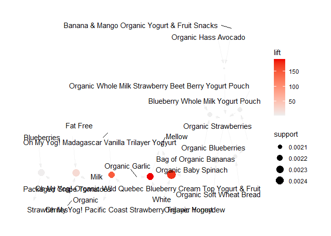

```r
plot(more_rules[1:10], method = "graph")
```